# Lab: p-values, GORIC(A), and Bayes factor

This lab material consists of multiple exercises regarding (informative) hypothesis evaluation using p-values, the GORIC(A), and the Bayes factor.

## Exercise 1: NHT, GORIC, and BF (ANOVA)

### Data

All sub-exercises will be applied to the same data set: a simulated data set based on the Sesame Street data (Stevens, 1996), which is included as the dataset ‘sesamsim’ in the bain package. Thus, upon installing and loading the bain package, the sesamsim data set is automatically imported.

```r
# Install and load packages
#
# Install and load the bain library because it contains the data 'sesamesim'
if (!require("bain")) install.packages("bain") # install this package first (once)
library(bain) # for the data 'sesamesim' and for the function bain
#
if (!require("restriktor")) install.packages("restriktor") # install this package first (once)
library(restriktor) # for the function goric
#
if (!require("psych")) install.packages("psych") # install this package first (once)
library(psych) # for the function describeBy

# load the data set
data(sesamesim)
```

Since the exercises concern the effect of the children’s background on its increase in knowledge of numbers after watching Sesame street for one year, some data wrangling is required first. That is, a change score variable (i.e., the dependent variable) needs to be created, capturing the difference in knowledge after one year. To create the dependent variable, the children’s knowledge of numbers at baseline (prenumb) is subtracted from its knowledge of number after watching Sesame street for one year (postnumb):

```r
# create change score variable
sesamesim$post_pre <- sesamesim$postnumb - sesamesim$prenumb
```

In addition to the dependent variable, the grouping variable (site) needs to be transformed into a factor. The variable represents the background of a child and consists of 5 categories:

- disadvantaged inner city,
- advantaged suburban,
- advantaged rural,
- disadvantaged rural,
- disadvantaged Spanish speaking.

```r
# convert 'site' into a factor
sesamesim$site <- factor(sesamesim$site)
```

### Hypotheses

Assume that a group of researchers has come up with the following expectations:  
A. Children from a suburban advantaged background improve more than children from a rural one.  
B. Children from an advantaged background improve more than children from a disadvantaged background (for both 1. rural and 2. suburban).

More precisely:  
- A. In the advantaged suburban area (Group 2), the difference in knowledge of numbers is larger than in the advantaged rural area (Group 3):  
$\mu_2 > \mu_3$.  
- B1. In the advantaged rural area (Group 3), the difference in knowledge of numbers is larger than in the disadvantaged rural area (Group 4):  
$\mu_3 > \mu_4$.  
- B2. In the advantaged suburban region (Group 2), the difference in knowledge of numbers is larger than in the disadvantaged inner city (Group 1) and disadvantaged Spanish speaking area (Group 5):  
$\mu_2 > (\mu_1, \mu_5)$.

The researchers want to evaluate the expectations simultaneously, that is, they want to evaluate the following theory-based hypothesis:
$$H_1: \mu_2 > \mu_3 > \mu_4, \mu_2
> (\mu_1, \mu_5),$$
that is,
$$H_1:
\mu_2 > \mu_3 > \mu_4, \ \mu_2 > \mu_1, \ \mu_2 >
\mu_5.$$

The goal of this exercise is to evaluate this hypothesis using a one-way ANOVA with `site` as the grouping variable and the newly created change score variable `post_pre` as the dependent variable.

### Exercise 1a: Classical Null Hypothesis Testing (NHT)

In this exercise, evaluate the aforementioned hypothesis using classical null hypothesis testing.

### Exercise 1b: The GORIC

In this exercise, evaluate the aforementioned theory-based hypothesis using the GORIC (or better: the ratio of GORIC weights).

**Click to show which steps are needed**

- Read the data; e.g., use read.table().
- Create factor(s); e.g., use factor().
- Inspect data; e.g., use describeBy().
- Estimate linear model; use lm().
- Specify informative hypothesis/-es  
  (which should be known before seeing the data).
- Apply GORIC; use goric() from restriktor package.
- Interpret output  
  (possibly using `Guidelines_output_GORIC.html’ from https://github.com/rebeccakuiper/Tutorials).

**Click to show notes on specifying hypotheses for goric()**

- It is possible to use the following operators: `>`, `<`, `=`, `==`,`<=`or`>=` within the `goric()` function.
  - `==` operator is interpreted in the same fashion as the `=`, meaning an equality.
  - `<=` and `>=` operators are the same as `<` and `>`, respectively, denoting inequality constraints (i.e., smaller and larger than, respectively).
- The `goric()` function can deal with:
  - pairwise restrictions (e.g., “beta1 > beta2; beta2 < beta3”); one can also use a “&” or “,” to separate the restrictions within one hypothesis.
  - combined restrictions (e.g., “beta1 > beta2 < beta3”)
- One can use ‘abs()’ in case one wants to specify an absolute strength/effect (e.g., abs(beta1) > abs(beta2); abs(beta2) > abs(beta3)).

Remark:  
* In a paper, hypotheses are specified in terms of population model parameters (often expressed as Greek letters).  
* In R, hypotheses are specified in terms of  
- the names of variables to which the parameters of interest belong to and/or  
- the assigned labels of the parameters of interest.

### Exercise 1c: The Bayes Factor

In this exercise, evaluate the aforementioned theory-based hypothesis using a Bayes factor.

## Exercise 2: Benchmarks

The GORIC(A) weights and the (Bayesian) posterior model probabilities (PMPs) nicely quantify the support for your hypothesis of interest. Even though it is easily interpreted, you may have noticed that sometimes it is hard to label the support. In a way, we do not want to label it, because cut-off points can invoke questionable research practices, but benchmarks do ease the interpretation even further. Let us, therefore, inspect benchmarks for the GORIC(A). The R package `restriktor` contains a `benchmark` function.

The `benchmark` function renders benchmarks that are study-specific, that is, if another hypothesis and/or other (numbers of) parameters and/or another statistical model is used, the benchmark values change.  
The benchmark function uses a pre-specified null population, but one can also specify one or more other null population.

The benchmark function gives the distribution of ratios of GORIC(A) weights (and more) under one ore more null populations and under the population based on the sample. The benchmarks under the null then reflect how extreme your finding is when that null population would be true.  
More information can be found on the github repository https://github.com/rebeccakuiper/Tutorials:  
- ‘Guidelines_GORIC-benchmarks’ (html or pdf) and  
- ‘Hands-on_123_Extra_Benchmarks_ANOVA_restriktor.R’ (in the Hands-on files folder).

Exercise: When looking at the ratio of GORIC weights from Exercise 1, how would you label that (using the benchmark function)?

**Click to see benchmark code**

```r
# If ANOVA model:
benchmarks_means <- benchmark(goric_object, model_type = "means", ncpus = 8)
benchmarks_means
plot(benchmarks_means)
# Use 'pop_es' to specify own null population(s).
#
## If ANOVA or other model:
benchmarks_asymp <- benchmark(goric_object, ncpus = 8)
# 'model_type = "asymp"', the default
benchmarks_asymp
plot(benchmarks_asymp)
# Use 'pop_est' to specify own null population(s).
#
#
# print() options:
# output_type = c("rgw", "gw", "rlw", "ld", "all")
# hypo_rate_threshold = <number>
#
# plot() options:
# output_type = c("rgw", "gw", "rlw", "ld")
# percentiles = NULL
# x_lim = c(<min>, <max>)
# log_scale = FALSE/TRUE
#
#
# I will use the ANOVA / means benchmarks code.
```

# Exercise 3: GORICA (latent regression)

In this exercise, we will inspect a latent regression model; using the ‘sesamesim’ data from Exercise 1.

The exercise concerns the effect of watching one year of the tv-series “Sesame Street” on the knowledge of numbers of N = 240 children aged between 34 and 69 months. Several variables have been measured before and after watching Sesame Street for one year: Knowledge of numbers before (Bn) and after (An) watching, and analogously, knowledge of body parts (Bb and Ab), letters (Bl and Al), forms (Bf and Af), relationships (Br and Ar), and classifications (Bc and Ac). The score ranges on these variables ranges from ‘1 to 20’ to ’1 to 70‘. In the exercises, we will use these variables as well as the following ones: biological age in months (age; score range: 34 to 69) and the Peabody test measuring the mental age of children (peabody; score range: 15 to 89).

In this exercise, we will inspect the model, in which the A(fter) measurements (i.e., Ab, Al, Af, An, Ar, and Ac) load on the factor A, and the B(efore) measurements load on the factor B. In addition, A is regressed on B, age, and peabody, to investigate whether children’s knowledge after watching Sesame Street for a year is predicted by their knowledge one year before, as well as by their biological and mental age, which have a correlation of

```r
cor(sesamesim$peabody, sesamesim$age)
```

```
## [1] 0.2396424
```

($\approx .24$); so, there is no multicollinearity.

The latent regression model is specified and run with the lavaan package as follows:

```r
# install this package first (once)
if (!require("lavaan")) install.packages("lavaan")
# Load
library(lavaan)
# Needed to run a SEM model, like the latent regression model.

#Specification of the latent regression model in lavaan
model <- '
    A =~ Ab + Al + Af + An + Ar + Ac
    B =~ Bb + Bl + Bf + Bn + Br + Bc
    A ~ AB*B + AAge*age + APeabody*peabody'
# Fit the model
fit <- sem(model, data = sesamesim, std.lv = TRUE)
```

It is a good practice to draw the SEM model you plan to estimate:

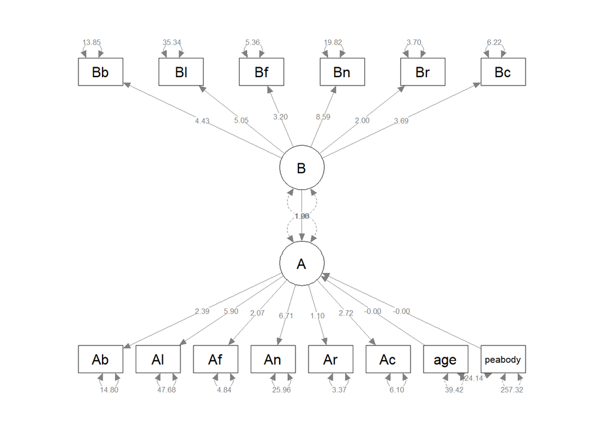

```r
# install this package first (once)
if (!require("semPlot")) install.packages("semPlot")
library(semPlot)

# plot
semPaths(fit, "par", weighted = FALSE, nCharNodes = 7, shapeMan = "rectangle",
         sizeMan = 8, sizeMan2 = 5)
```

Come up with one or more informative, theory-based hypotheses and a failsafe hypothesis (this could be about the factor loadings and/or the regression parameters).

**Click to show information on the hypotheses used in the answers**

In the solution, we evaluate three theory-based hypotheses (H1-H3) on standardized regression coefficients. Since these three do not cover all the possible theories, we include the unconstrained as failsafe.

- **H1** specifies that a larger score on B corresponds to a larger score on A (i.e., a positive relation between B and A) and that age and peabody do not predict A.
- **H2** specifies that the positive relation between B and A is stronger than the positive relation between peabody and A and that age cannot be used to predict A.
- **H3** specifies that the predictive power of B is larger than that of peabody, which, in turn, is larger than that of age which in turn is positive.

Notably, only in case all these hypotheses are of interest, these should all be included in the set; especially if there is overlap like here (see the article: https://doi-org.proxy.library.uu.nl/10.1080/10705511.2020.1836967 and/or ‘Guidelines_output_GORIC.html’ on https://github.com/rebeccakuiper/Tutorials for more information).

Evaluate the hypotheses with the GORICA: Interpret the output. What are your conclusions?

### Exercise 3 (Optional): Alternative input

Do the same evaluation as above, but now use the (standardized) estimates and their covariance matrix as input to the goric function (instead of the lavaan object). E.g., use:

```
`goric(est, VCOV = vcov, hypotheses = list(H1),
       #type = "gorica" # default
       comparison = "complement")`
```

with `est` the (standardized) estimates and `vcov` their covariance matrix.

## Exercise 4 (Optional): The sky is the limit

You can try out evaluating informative, theory-based hypotheses using other data sets; for example, one or more from the subfolder ‘data’ on the github repository https://github.com/rebeccakuiper/Tutorials or perhaps from https://openpsychometrics.org.

You can also look into other types of models (e.g., SEM and (RI-)CLPM).  
Examples files for the GORIC(A) can be found on https://github.com/rebeccakuiper/Tutorials. In ’_README.md’, you can find an overview of the (example and tutorial) files.

You can of course, when available, also use your own data.